# LAB1

# Ejercicio 4.11 - ¿Cómo se correlacionan los presupuestos con los ingresos? ¿Los altos

presupuestos significan altos ingresos? Haga los gráficos que necesite, histograma, diagrama de dispersión

```r
# Correlacion numerica
correlacion <- cor(movies$budget, movies$revenue, use = "complete.obs")
print(paste("Coeficiente de correlación:", round(correlacion, 4)))
```

```
## [1] "Coeficiente de correlación: 0.7758"
```

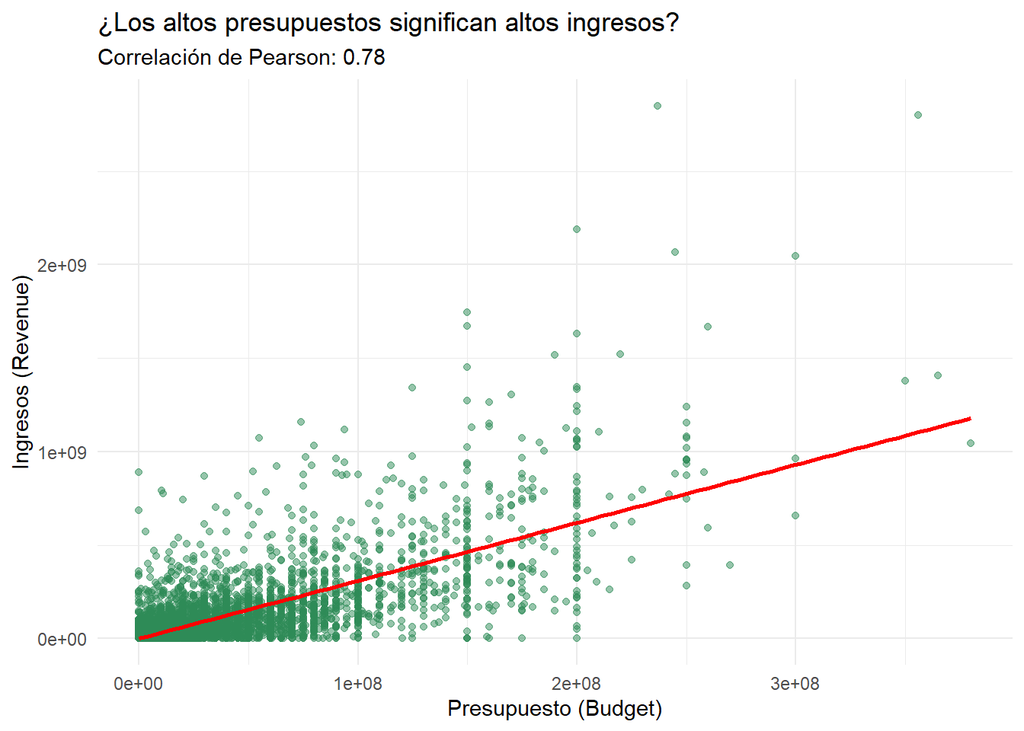

```r
# Diagrama de dispersión
grafico_dispersion <- ggplot(movies, aes(x = budget, y = revenue)) +
  # Color verde para los puntos
  geom_point(alpha = 0.5, color = "#2E8B57") +
  # Línea de tendencia roja
  geom_smooth(method = "lm", color = "red", se = FALSE) +
  labs(title = "¿Los altos presupuestos significan altos ingresos?",
       subtitle = paste("Correlación de Pearson:", round(correlacion, 2)),
       x = "Presupuesto (Budget)",
       y = "Ingresos (Revenue)") +
  theme_minimal()

# Histograma de presupuestos
hist_presupuesto <- ggplot(movies, aes(x = budget)) +
  geom_histogram(bins = 40, fill = "#4682B4", color = "white") +
  labs(title = "Distribución de los Presupuestos",
       x = "Presupuesto ($)",
       y = "Cantidad de Películas") +
  theme_minimal()

# Histograma de Ingresos
hist_ingresos <- ggplot(movies, aes(x = revenue)) +
  geom_histogram(bins = 40, fill = "#E9967A", color = "white") +
  labs(title = "Distribución de los Ingresos",
       x = "Ingresos ($)",
       y = "Cantidad de Películas") +
  theme_minimal()

# Mostrar gráficos
print(grafico_dispersion)
```

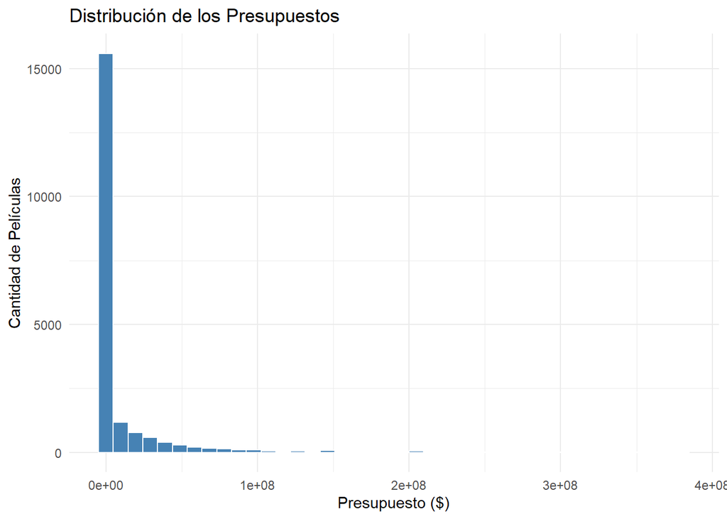

```r
print(hist_presupuesto)
```

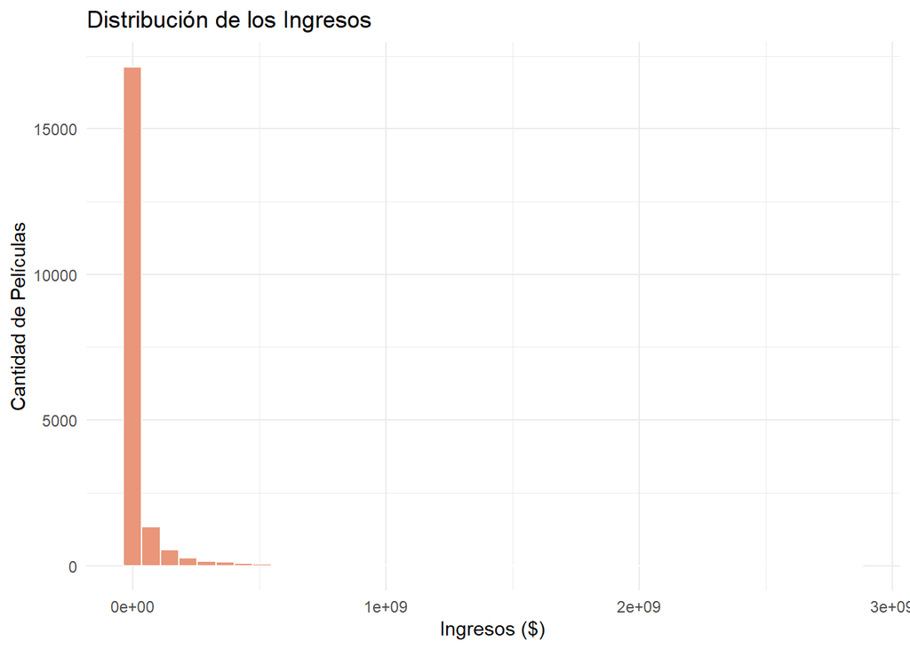

```r
print(hist_ingresos)
```

El análisis estadístico arroja un coeficiente de correlación de Pearson de 0.78, lo que confirma una relación positiva fuerte entre el presupuesto y los ingresos. Como se visualiza en el diagrama de dispersión, existe una tendencia clara donde una mayor inversión suele traducirse en mayores ganancias; sin embargo, la dispersión de los puntos indica que el éxito no está garantizado, existiendo películas de alto costo con retornos inferiores a lo esperado. Por su parte, los histogramas revelan que ambas variables presentan una distribución extremadamente sesgada a la derecha (no normal), lo que demuestra que la industria cinematográfica se compone mayoritariamente de producciones de bajo y mediano presupuesto, siendo las “superproducciones” multimillonarias casos excepcionales y atípicos dentro del conjunto de datos.

# Ejercicio 4.12 - ¿Se asocian ciertos meses de lanzamiento con mejores ingresos?

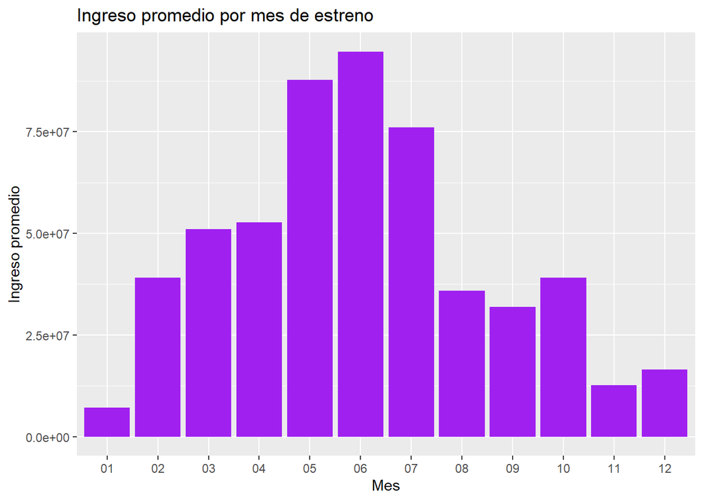

```r
movies <- movies %>%
  mutate(
    releaseDate = as.Date(releaseDate),
    releaseMonth = format(releaseDate, "%m")
  )

movies %>%
  filter(!is.na(releaseMonth), !is.na(revenue)) %>%
  group_by(releaseMonth) %>%
  summarise(ingreso_promedio = mean(revenue, na.rm = TRUE)) %>%
  ggplot(aes(x = releaseMonth, y = ingreso_promedio)) +
  geom_col(fill = "purple") +
  labs(
    title = "Ingreso promedio por mes de estreno",
    x = "Mes",
    y = "Ingreso promedio"
  )
```

Como se puede observar, los meses de mayo y junio concentran mayores ingresos promedio, lo cual sugiere que el momento del estreno influye en el desempeño financiero de las películas al ser épocas donde las personas obtienen mucho tiempo libre tales como las vacaciones de medio año para colegios.

# Ejercicio 4.13 - ¿En qué meses se han visto los lanzamientos con mejores ingresos?

¿cuantas películas, en promedio, se han lanzado por mes?

```r
movies %>%
  filter(!is.na(releaseMonth)) %>%
  group_by(releaseMonth) %>%
  summarise(
    peliculas = n(),
    ingreso_promedio = mean(revenue, na.rm = TRUE)
  ) %>%
  arrange(desc(ingreso_promedio))
```

```
## # A tibble: 12 × 3
##    releaseMonth peliculas ingreso_promedio
##    <chr>            <int>            <dbl>
##  1 06                 819        94747108.
##  2 05                 699        87719769.
##  3 07                 812        76028696.
##  4 04                 695        52671273.
##  5 03                 816        51053300.
##  6 02                 774        39138627.
##  7 10                1064        39133157.
##  8 08                 914        35930725.
##  9 09                1078        31958536.
## 10 12                4361        16517826.
## 11 11                4730        12700099.
## 12 01                3119         7127284.
```

Al igual que en el inciso 4.12, Junio coincide como el mes con mayor demanda cinematográfica.

# Ejercicio 4.14 - ¿Cómo se correlacionan las calificaciones con el éxito comercial?

```r
# Correlacion numerica para ver si van de la mano o no
cor_calif_ingreso <- cor(movies$voteAvg, movies$revenue, use = "complete.obs")
print(paste("Coeficiente de correlación:", round(cor_calif_ingreso, 4)))
```

```
## [1] "Coeficiente de correlación: 0.2303"
```

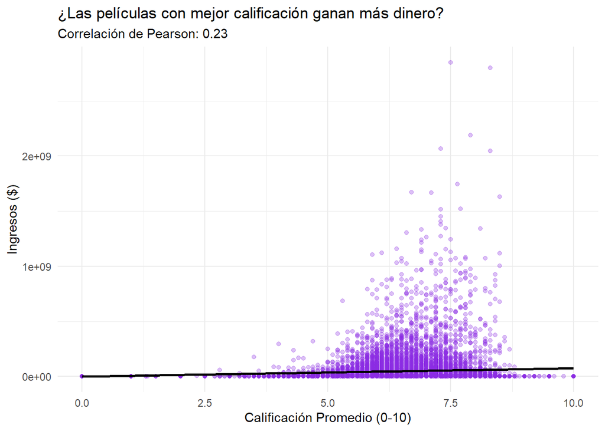

```r
# Grafico de dispersion
grafico_exit_comercial <- ggplot(movies, aes(x = voteAvg, y = revenue)) +
  geom_point(alpha = 0.3, color = "#8A2BE2") +
  geom_smooth(method = "lm", color = "black", se = FALSE) +
  labs(title = "¿Las películas con mejor calificación ganan más dinero?",
       subtitle = paste("Correlación de Pearson:", round(cor_calif_ingreso, 2)),
       x = "Calificación Promedio (0-10)",
       y = "Ingresos ($)") +
  theme_minimal()

print(grafico_exit_comercial)
```

El cálculo del coeficiente de correlación de Pearson arroja un valor de 0.23, lo cual evidencia una relación positiva débil entre la calidad percibida (calificación promedio) y el éxito comercial. Al observar el diagrama de dispersión, la nube de puntos no sigue un patrón lineal definido, sino que muestra una gran dispersión: existen numerosas películas con calificaciones excelentes (superiores a 8.0) que obtuvieron ingresos modestos, mientras que producciones con calificaciones promedio (entre 6.0 y 7.0) alcanzaron recaudaciones multimillonarias. Esto concluye que la valoración crítica de la audiencia no es un predictor fiable de la taquilla, y que el éxito financiero depende mayoritariamente de otros factores como el marketing, el presupuesto o la pertenencia a franquicias populares, más que de la “calidad” cinematográfica en sí misma.

# Ejercicio 4.15 - ¿Qué estrategias de marketing, como videos promocionales o páginas

oficiales, generan mejores resultados?

```r
movies <- movies |>
  mutate(
    tiene_homepage = ifelse(is.na(homePage) | homePage == "", "No", "Sí")
  )

movies |>
  filter(!is.na(video)) |>
  group_by(video, tiene_homepage) |>
  summarise(
    ingreso_promedio = mean(revenue, na.rm = TRUE),
    popularidad_promedio = mean(popularity, na.rm = TRUE),
    peliculas = n(),
    .groups = "drop"
  )
```

```
## # A tibble: 4 × 5
##   video tiene_homepage ingreso_promedio popularidad_promedio peliculas
##   <lgl> <chr>                     <dbl>                <dbl>     <int>
## 1 FALSE No                    12508277.                 14.1     14048
## 2 FALSE Sí                    57762297.                 50.3      5265
## 3 TRUE  No                      423701.                 39.0        60
## 4 TRUE  Sí                      712829.                 60.6        24
```

Podemos concluir que la existencia de una página oficial se asocia con mayores ingresos y niveles de popularidad. Asimismo, las películas que combinan video promocional y página oficial presentan la mayor popularidad promedio. Aunque algunos grupos presentan un número reducido de observaciones, la tendencia general sugiere que una estrategia de marketing digital más completa genera mejores resultados.

# Ejercicio 4.16 - ¿La popularidad del elenco está directamente correlacionada con el éxito

de taquilla?

```r
# Coeficiente de correlacion
cor_actores <- cor(movies$actorsPopularity, movies$revenue, use = "complete.obs")
print(paste("Coeficiente de correlación:", round(cor_actores, 4)))
```

```
## [1] "Coeficiente de correlación: 0.0549"
```

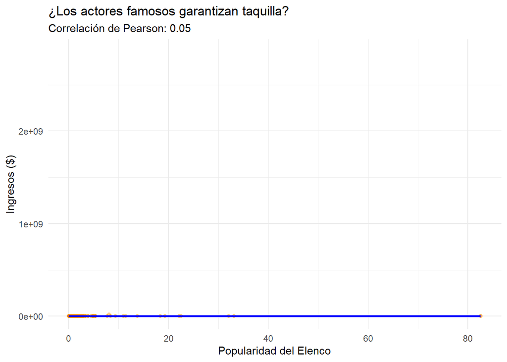

```r
# Grafico de dispersion
grafico_elenco_exit <- ggplot(movies, aes(x = actorsPopularity, y = revenue)) +
  geom_point(alpha = 0.4, color = "#FF8C00") + # Color Naranja (Dark Orange)
  geom_smooth(method = "lm", color = "blue", se = FALSE) + # Línea de tendencia azul
  labs(title = "¿Los actores famosos garantizan taquilla?",
       subtitle = paste("Correlación de Pearson:", round(cor_actores, 2)),
       x = "Popularidad del Elenco",
       y = "Ingresos ($)") +
  theme_minimal()

print(grafico_elenco_exit)
```

El análisis estadístico arroja un coeficiente de correlación de Pearson de 0.05, lo cual indica una correlación nula. Contrario a la creencia popular de que el “Star Power” impulsa la taquilla, los datos de esta muestra revelan que no existe ninguna relación lineal entre la popularidad del elenco y los ingresos generados. Como se observa en el gráfico, la línea de tendencia es completamente plana (horizontal), demostrando que películas con actores de alta popularidad no recaudaron necesariamente más que aquellas con elencos desconocidos. Esto sugiere que, al menos en este conjunto de datos depurado, la fama de los actores es irrelevante para predecir el éxito financiero.